# variable_transformation

taehoon

2016년 11월 21일

## 변수 변환(variable transformation)

### step 1 데이터 확인하기(trees)

```r
trees
```

```
##    Girth Height Volume
## 1    8.3     70   10.3
## 2    8.6     65   10.3
## 3    8.8     63   10.2
## 4   10.5     72   16.4
## 5   10.7     81   18.8
## 6   10.8     83   19.7
## 7   11.0     66   15.6
## 8   11.0     75   18.2
## 9   11.1     80   22.6
## 10  11.2     75   19.9
## 11  11.3     79   24.2
## 12  11.4     76   21.0
## 13  11.4     76   21.4
## 14  11.7     69   21.3
```

[output cut: 17 more lines]

```r
head(trees)
```

```
##   Girth Height Volume
## 1   8.3     70   10.3
## 2   8.6     65   10.3
## 3   8.8     63   10.2
## 4  10.5     72   16.4
## 5  10.7     81   18.8
## 6  10.8     83   19.7
```

### step 2 높이와 부피의 산점도를 그려서 선형관계 확인

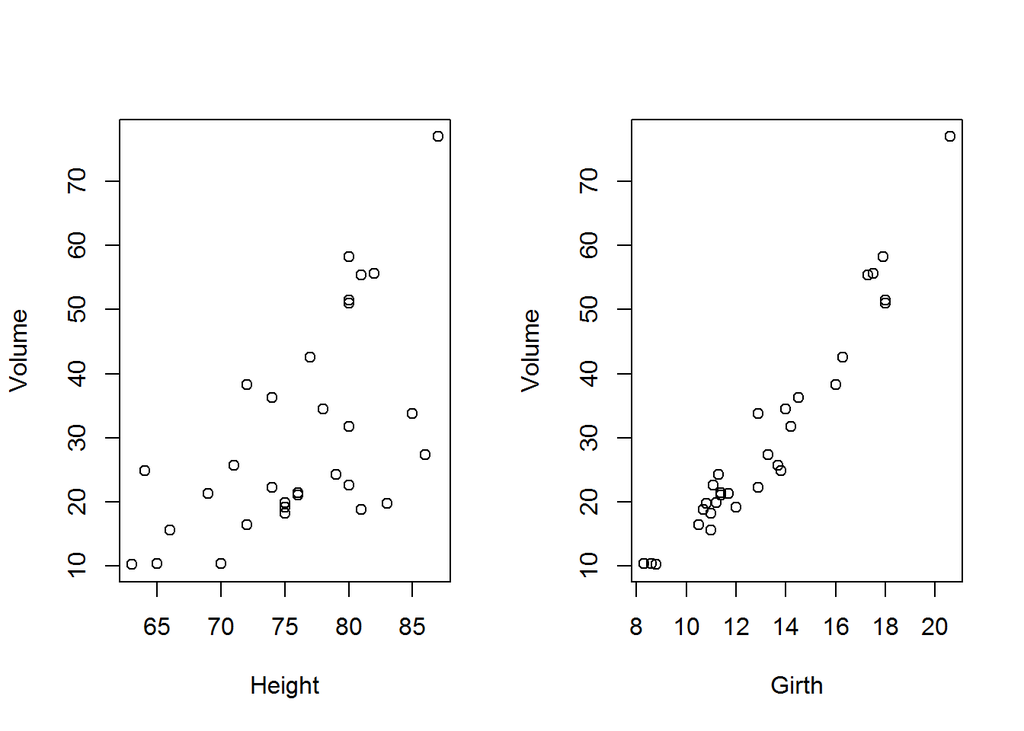

```r
attach(trees)
par(mfrow=c(1,2))
plot(Height,Volume)
plot(Girth,Volume)
```

### step 3 Volume과 Girth의 회귀식을 추정하자. 변수변환 없이 회귀식 추정

```r
my_lm <- lm(Volume ~ Girth)
summary(my_lm)
```

```
##
## Call:
## lm(formula = Volume ~ Girth)
##
## Residuals:
##    Min     1Q Median     3Q    Max
## -8.065 -3.107  0.152  3.495  9.587
##
## Coefficients:
##             Estimate Std. Error t value Pr(>|t|)
## (Intercept) -36.9435     3.3651  -10.98 7.62e-12 ***
## Girth         5.0659     0.2474   20.48  < 2e-16 ***
## ---
## Signif. codes:  0 '***' 0.001 '**' 0.01 '*' 0.05 '.' 0.1 ' ' 1
##
## Residual standard error: 4.252 on 29 degrees of freedom
## Multiple R-squared:  0.9353, Adjusted R-squared:  0.9331
## F-statistic: 419.4 on 1 and 29 DF,  p-value: < 2.2e-16
```

p 값이 0.05보다 작으므로 유의하게 나왔고, R^2가 0.9353이 나왔으므로 적합이 잘 되었다고 볼 수 있다.

### step 4 Volume자료의 회귀식 적합과 잔차 그림을 그려 곡선 형태가 나타나는 것을 확인

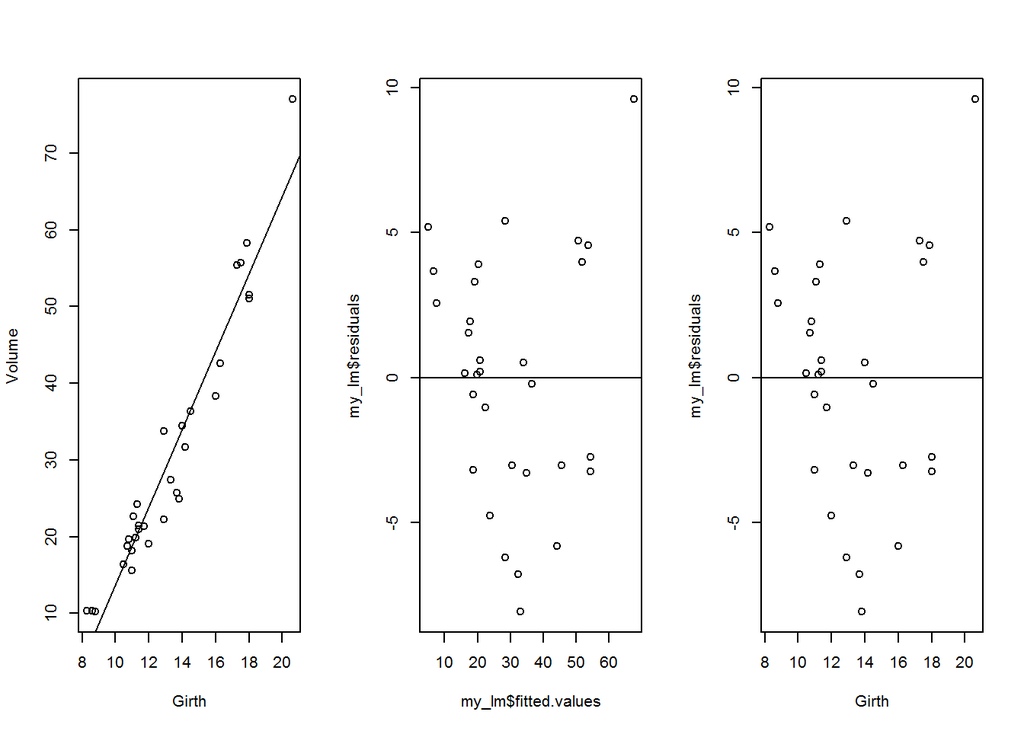

```r
par(mfcol=c(1,3))
plot(Girth,Volume)
abline(my_lm)
plot(my_lm$fitted.values, my_lm$residuals)
abline(h=0)
plot(Girth, my_lm$residuals)
abline(h=0)
```

적합과 잔차그림을 그려본 결과 곡선형태가 나타나는 것을 볼 수 있다.

### step 5 Volume을 log(volume)로 치환하여 회귀식을 구해 적합성 확인

```r
log_Volume = log(Volume)
my_lm_log <- lm(log_Volume~Girth)
summary(my_lm_log)
```

```
##
## Call:
## lm(formula = log_Volume ~ Girth)
##
## Residuals:
##      Min       1Q   Median       3Q      Max
## -0.22719 -0.11468  0.02889  0.07930  0.30436
##
## Coefficients:
##             Estimate Std. Error t value Pr(>|t|)
## (Intercept) 1.118997   0.104021   10.76 1.23e-11 ***
## Girth       0.162566   0.007647   21.26  < 2e-16 ***
## ---
## Signif. codes:  0 '***' 0.001 '**' 0.01 '*' 0.05 '.' 0.1 ' ' 1
##
## Residual standard error: 0.1314 on 29 degrees of freedom
## Multiple R-squared:  0.9397, Adjusted R-squared:  0.9376
## F-statistic:   452 on 1 and 29 DF,  p-value: < 2.2e-16
```

반응변수 Volume을 로그변환하여 회귀식을 구해 확인해봤다. p값이 0.05.보다 작고 R2값이 0.9397으로 적합이 잘 되었다고 볼 수 있다.

### step 6 log(Volume) 자료의 회귀식 적합과 잔차그림을 그려보자

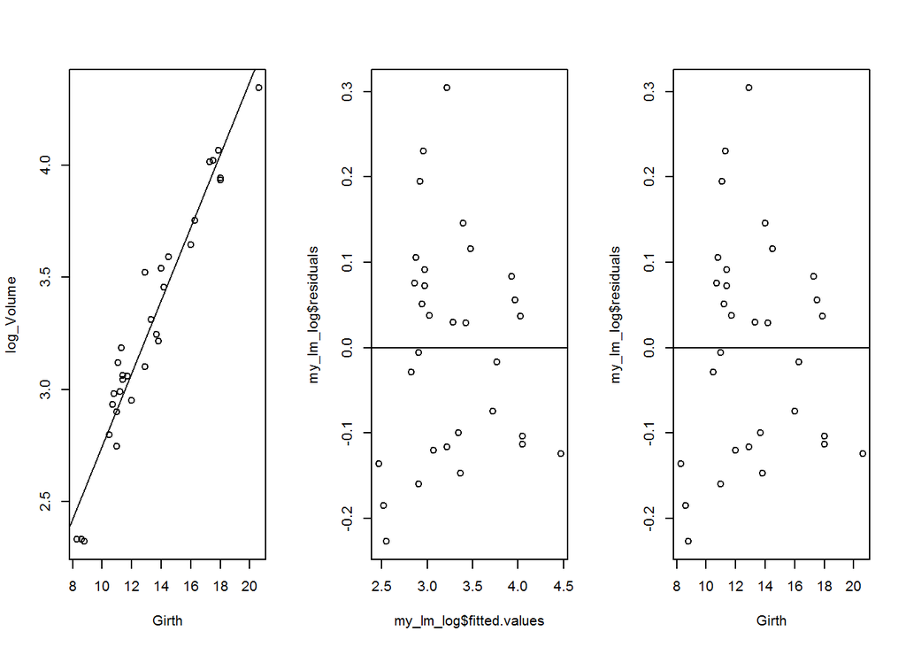

```r
par(mfcol=c(1,3))
plot(Girth,log_Volume)
abline(my_lm_log)
plot(my_lm_log$fitted.values, my_lm_log$residuals)
abline(h=0)
plot(Girth, my_lm_log$residuals)
abline(h=0)
```

전의 잔차그림과 비교하면 곡선채턴이 많이 없어진 것을 볼 수 있다.

### step 7 Girth를 log(Girth), Volume을 log(Volume)로 치환하여 회귀식을 구해보자

```r
log_Girth = log(Girth)
my_lm_log1 <- lm(log_Volume~log_Girth)
summary(my_lm_log1)
```

```
##
## Call:
## lm(formula = log_Volume ~ log_Girth)
##
## Residuals:
##       Min        1Q    Median        3Q       Max
## -0.205999 -0.068702  0.001011  0.072585  0.247963
##
## Coefficients:
##             Estimate Std. Error t value Pr(>|t|)
## (Intercept) -2.35332    0.23066  -10.20 4.18e-11 ***
## log_Girth    2.19997    0.08983   24.49  < 2e-16 ***
## ---
## Signif. codes:  0 '***' 0.001 '**' 0.01 '*' 0.05 '.' 0.1 ' ' 1
##
## Residual standard error: 0.115 on 29 degrees of freedom
## Multiple R-squared:  0.9539, Adjusted R-squared:  0.9523
## F-statistic: 599.7 on 1 and 29 DF,  p-value: < 2.2e-16
```

역시 p값이 0.05보다 작고 R2값이 0.9539가 나왔으므로 적합이 잘 되었다고 볼 수 있다.

### step8 log(Girth), log(Volume)자료의 회귀식 적합과 잔차그림을 그려보자

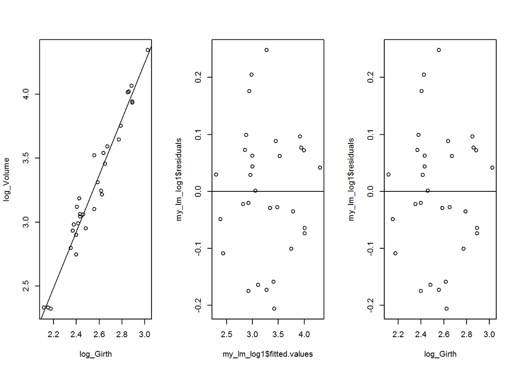

```r
par(mfcol=c(1,3))
plot(log_Girth,log_Volume)
abline(my_lm_log1)
plot(my_lm_log1$fitted.values, my_lm_log1$residuals)
abline(h=0)
plot(log_Girth, my_lm_log1$residuals)
abline(h=0)
```

전보다 잔차그림의 곡선패턴이 많이 없어진 것을 볼 수 있다.